# pdf-html

Practical Machine Learning Course Project

Suhas 23/10/2021

Background

Using devices such as Jawbone Up, Nike FuelBand, and Fitbit it is now possible to collect a large amount of data about personal activity relatively inexpensively. These type of devices are part of the quantified self movement – a group of enthusiasts who take measurements about themselves regularly to improve their health, to find patterns in their behavior, or because they are tech geeks. One thing that people regularly do is quantify how much of a particular activity they do, but they rarely quantify how well they do it. In this project, your goal will be to use data from accelerometers on the belt, forearm, arm, and dumbell of 6 participants. They were asked to perform barbell lifts correctly and incorrectly in 5 different ways. More information is available from the website here: http://web.archive.org/web/20161224072740/http:/groupware.les.inf.puc-rio.br/har [(http://web.archive.org/web/20161224072740/http:/groupware.les.inf.puc-rio.br/har)](http://web.archive.org/web/20161224072740/http:/groupware.les.inf.puc-rio.br/har) (see the section on the Weight Lifting Exercise Dataset).

Data

The training data for this project are available here:

https://d396qusza40orc.cloudfront.net/predmachlearn/pml-training.csv [(https://d396qusza40orc.cloudfront.net /predmachlearn/pml-training.csv)](https://d396qusza40orc.cloudfront.net/predmachlearn/pml-training.csv)

The test data are available here:

https://d396qusza40orc.cloudfront.net/predmachlearn/pml-testing.csv [(https://d396qusza40orc.cloudfront.net /predmachlearn/pml-testing.csv)](https://d396qusza40orc.cloudfront.net/predmachlearn/pml-testing.csv)

The data for this project come from this source:

http://web.archive.org/web/20161224072740/http:/groupware.les.inf.puc-rio.br/har [(http://web.archive.org /web/20161224072740/http:/groupware.les.inf.puc-rio.br/har)](http://web.archive.org/web/20161224072740/http:/groupware.les.inf.puc-rio.br/har). If you use the document you create for this class for any purpose please cite them as they have been very generous in allowing their data to be used for this kind of assignment.

Choosing the prediction algorithm

Steps Taken

1.Tidy data. Remove columns with little/no data.

2.Create Training and test data from traing data for cross validation checking

[figure not shown]

Introduction

Using devices such as Jawbone Up, Nike FuelBand, and Fitbit it is now possible to collect a large amount of data about personal activity relatively inexpensively. These type of devices are part of the quantified self movement – a group of enthusiasts who take measurements about themselves regularly to improve their health, to find patterns in their behavior, or because they are tech geeks. One thing that people regularly do is quantify how much of a particular activity they do, but they rarely quantify how well they do it.

In this project, we will use data from accelerometers on the belt, forearm, arm, and dumbell of 6 participants to predict the manner in which they did the exercise.

Data Preprocessing

library(lattice) library(ggplot2) library(caret)

## Warning: package 'caret' was built under R version 4.0.5

library(kernlab)

##

library(rattle)

library(corrplot)

[figure not shown]

## corrplot 0.90 loaded

set.seed(1234)

Read the Data

After downloading the data from the data source, we can read the two csv files into two data frames.

traincsv <- read.csv("./data/pml-training.csv") testcsv <- read.csv("./data/pml-testing.csv") dim(traincsv)

##[1] 19622 160

dim(testcsv)

##[1] 20 160

The training data set contains 19622 observations and 160 variables, while the testing data set contains 20 observations and 160 variables. The “classe” variable in the training set is the outcome to predict.

Clean the data

Removing unnecessary variables. Starting with N/A variables.

traincsv <- traincsv[,colMeans(is.na(traincsv)) < .9] #removing mostly na columns traincsv <- traincsv[,-c(1:7)]#removing metadata which is irrelevant to the outcome

Removing near zero variance variables.

nvz <- nearZeroVar(traincsv) traincsv <- traincsv[,-nvz] dim(traincsv)

| ## [1] 19622 | 53 |
| --- | --- |

Now that we have finished removing the unnecessary variables, we can now split the training set into a validation and sub training set. The testing set “testcsv” will be left alone, and used for the final quiz test cases.

inTrain <- createDataPartition(y=traincsv$classe, p=0.7, list=F) train <- traincsv[inTrain,]

valid <- traincsv[-inTrain,]

Creating and Testing the Models

[figure not shown]

Here we will test a few popular models including: Decision Trees, Random Forest, Gradient Boosted Trees, and SVM. This is probably more than we will need to test, but just out of curiosity and good practice we will run them for comparison.

Set up control for training to use 3-fold cross validation.

control <- trainControl(method="cv", number=3, verboseIter=F)

Decision Tree

Model:

mod_trees <- train(classe~., data=train, method="rpart", trControl = control, tuneLen gth = 5)

fancyRpartPlot(mod_trees$finalModel)

Prediction:

pred_trees <- predict(mod_trees, valid)

cmtrees <- confusionMatrix(pred_trees, factor(valid$classe)) cmtrees

##Confusion Matrix and Statistics

##Reference

| ## Prediction |  | A | B | C | D | E |
| --- | --- | --- | --- | --- | --- | --- |
| ## | A 1519 |  | 473 | 484 | 451 | 156 |
| ## | B | 28 | 355 | 45 | 10 | 130 |
| ## | C | 83 | 117 | 423 | 131 | 131 |
| ## | D | 40 | 194 | 74 | 372 | 176 |
| ## | E | 4 | 0 | 0 | 0 | 489 |
| ## |  |  |  |  |  |  |

##Overall Statistics

| ## | Accuracy | : | 0.5366 |
| --- | --- | --- | --- |
| ## | 95% CI | : | (0.5238, 0.5494) |

##No Information Rate : 0.2845

##P-Value [Acc > NIR] : < 2.2e-16

| ## | Kappa : 0.3957 |
| --- | --- |
| ## |  |

##Mcnemar's Test P-Value : < 2.2e-16

##Statistics by Class:

| ## |  |  |  |  |  |
| --- | --- | --- | --- | --- | --- |
| ## | Class: A Class: B Class: C Class: D Class: E |  |  |  |  |
| ## Sensitivity | 0.9074 | 0.31168 | 0.41228 | 0.38589 | 0.45194 |
| ## Specificity | 0.6286 | 0.95512 | 0.90492 | 0.90165 | 0.99917 |
| ## Pos Pred Value | 0.4927 | 0.62500 | 0.47797 | 0.43458 | 0.99189 |
| ## Neg Pred Value | 0.9447 | 0.85255 | 0.87940 | 0.88228 | 0.89002 |
| ## Prevalence | 0.2845 | 0.19354 | 0.17434 | 0.16381 | 0.18386 |
| ## Detection Rate | 0.2581 | 0.06032 | 0.07188 | 0.06321 | 0.08309 |
| ## Detection Prevalence | 0.5239 | 0.09652 | 0.15038 | 0.14545 | 0.08377 |
| ## Balanced Accuracy | 0.7680 | 0.63340 | 0.65860 | 0.64377 | 0.72555 |

Random Forest

mod_rf <- train(classe~., data=train, method="rf", trControl = control, tuneLength = 5)

pred_rf <- predict(mod_rf, valid)

cmrf <- confusionMatrix(pred_rf, factor(valid$classe)) cmrf

##Confusion Matrix and Statistics

##Reference

| ## Prediction |  | A | B | C | D | E |
| --- | --- | --- | --- | --- | --- | --- |
| ## | A 1673 |  | 4 | 0 | 0 | 0 |
| ## | B | 1 | 1132 | 8 | 0 | 0 |
| ## | C | 0 | 3 | 1016 | 5 | 1 |
| ## | D | 0 | 0 | 2 | 958 | 0 |
| ## | E | 0 | 0 | 0 | 1 | 1081 |
| ## |  |  |  |  |  |  |

##Overall Statistics

| ## | Accuracy | : | 0.9958 |
| --- | --- | --- | --- |
| ## | 95% CI | : | (0.9937, 0.9972) |

##No Information Rate : 0.2845

##P-Value [Acc > NIR] : < 2.2e-16

| ## | Kappa : 0.9946 |
| --- | --- |
| ## |  |

##Mcnemar's Test P-Value : NA

##Statistics by Class:

| ## |  |  |  |  |  |
| --- | --- | --- | --- | --- | --- |
| ## | Class: A Class: B Class: C Class: D Class: E |  |  |  |  |
| ## Sensitivity | 0.9994 | 0.9939 | 0.9903 | 0.9938 | 0.9991 |
| ## Specificity | 0.9991 | 0.9981 | 0.9981 | 0.9996 | 0.9998 |
| ## Pos Pred Value | 0.9976 | 0.9921 | 0.9912 | 0.9979 | 0.9991 |
| ## Neg Pred Value | 0.9998 | 0.9985 | 0.9979 | 0.9988 | 0.9998 |
| ## Prevalence | 0.2845 | 0.1935 | 0.1743 | 0.1638 | 0.1839 |
| ## Detection Rate | 0.2843 | 0.1924 | 0.1726 | 0.1628 | 0.1837 |
| ## Detection Prevalence | 0.2850 | 0.1939 | 0.1742 | 0.1631 | 0.1839 |
| ## Balanced Accuracy | 0.9992 | 0.9960 | 0.9942 | 0.9967 | 0.9994 |

Gradient Boosted Trees

mod_gbm <- train(classe~., data=train, method="gbm", trControl = control, tuneLength = 5, verbose = F)

pred_gbm <- predict(mod_gbm, valid)

cmgbm <- confusionMatrix(pred_gbm, factor(valid$classe)) cmgbm

##Confusion Matrix and Statistics

##Reference

| ## Prediction |  | A | B | C | D | E |
| --- | --- | --- | --- | --- | --- | --- |
| ## | A 1671 |  | 5 | 0 | 0 | 0 |
| ## | B | 1 | 1128 | 15 | 0 | 0 |
| ## | C | 2 | 6 | 1007 | 8 | 4 |
| ## | D | 0 | 0 | 4 | 953 | 1 |
| ## | E | 0 | 0 | 0 | 3 | 1077 |
| ## |  |  |  |  |  |  |

##Overall Statistics

| ## | Accuracy | : | 0.9917 |
| --- | --- | --- | --- |
| ## | 95% CI | : | (0.989, 0.9938) |

##No Information Rate : 0.2845

##P-Value [Acc > NIR] : < 2.2e-16

| ## | Kappa : 0.9895 |
| --- | --- |
| ## |  |

##Mcnemar's Test P-Value : NA

##Statistics by Class:

| ## |  |  |  |  |  |
| --- | --- | --- | --- | --- | --- |
| ## | Class: A Class: B Class: C Class: D Class: E |  |  |  |  |
| ## Sensitivity | 0.9982 | 0.9903 | 0.9815 | 0.9886 | 0.9954 |
| ## Specificity | 0.9988 | 0.9966 | 0.9959 | 0.9990 | 0.9994 |
| ## Pos Pred Value | 0.9970 | 0.9860 | 0.9805 | 0.9948 | 0.9972 |
| ## Neg Pred Value | 0.9993 | 0.9977 | 0.9961 | 0.9978 | 0.9990 |
| ## Prevalence | 0.2845 | 0.1935 | 0.1743 | 0.1638 | 0.1839 |
| ## Detection Rate | 0.2839 | 0.1917 | 0.1711 | 0.1619 | 0.1830 |
| ## Detection Prevalence | 0.2848 | 0.1944 | 0.1745 | 0.1628 | 0.1835 |
| ## Balanced Accuracy | 0.9985 | 0.9935 | 0.9887 | 0.9938 | 0.9974 |

Support Vector Machine

mod_svm <- train(classe~., data=train, method="svmLinear", trControl = control, tuneL ength = 5, verbose = F)

pred_svm <- predict(mod_svm, valid)

cmsvm <- confusionMatrix(pred_svm, factor(valid$classe)) cmsvm

[figure not shown]

##Confusion Matrix and Statistics

##Reference

| ## Prediction |  | A | B | C | D | E |
| --- | --- | --- | --- | --- | --- | --- |
| ## | A 1537 |  | 154 | 79 | 69 | 50 |
| ## | B | 29 | 806 | 90 | 46 | 152 |
| ## | C | 40 | 81 | 797 | 114 | 69 |
| ## | D | 61 | 22 | 32 | 697 | 50 |
| ## | E | 7 | 76 | 28 | 38 | 761 |
| ## |  |  |  |  |  |  |

##Overall Statistics

| ## | Accuracy | : | 0.7813 |
| --- | --- | --- | --- |
| ## | 95% CI | : | (0.7705, 0.7918) |

##No Information Rate : 0.2845

##P-Value [Acc > NIR] : < 2.2e-16

| ## | Kappa : 0.722 |
| --- | --- |
| ## |  |

##Mcnemar's Test P-Value : < 2.2e-16

##Statistics by Class:

| ## |  |  |  |  |  |
| --- | --- | --- | --- | --- | --- |
| ## | Class: A Class: B Class: C Class: D Class: E |  |  |  |  |
| ## Sensitivity | 0.9182 | 0.7076 | 0.7768 | 0.7230 | 0.7033 |
| ## Specificity | 0.9164 | 0.9332 | 0.9374 | 0.9665 | 0.9690 |
| ## Pos Pred Value | 0.8137 | 0.7177 | 0.7239 | 0.8086 | 0.8363 |
| ## Neg Pred Value | 0.9657 | 0.9301 | 0.9521 | 0.9468 | 0.9355 |
| ## Prevalence | 0.2845 | 0.1935 | 0.1743 | 0.1638 | 0.1839 |
| ## Detection Rate | 0.2612 | 0.1370 | 0.1354 | 0.1184 | 0.1293 |
| ## Detection Prevalence | 0.3210 | 0.1908 | 0.1871 | 0.1465 | 0.1546 |
| ## Balanced Accuracy | 0.9173 | 0.8204 | 0.8571 | 0.8447 | 0.8362 |

Predicting on Test Data Set

Running our test set to predict the classe (5 levels) outcome for 20 cases with the Random Forest model.

pred <- predict(mod_rf, testcsv) print(pred)

##[1] B A B A A E D B A A B C B A E E A B B B

##Levels: A B C D E

Appendix: Figures

1.correlation matrix of variables in training set

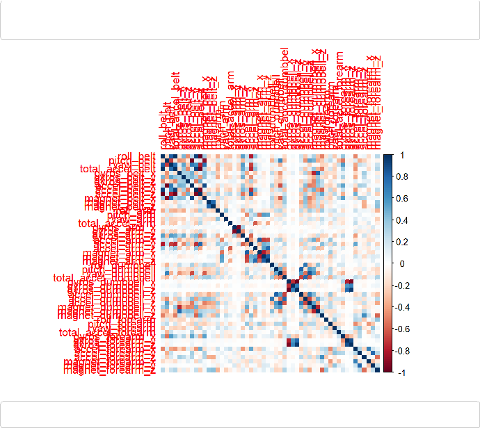

corrPlot <- cor(train[, -length(names(train))]) corrplot(corrPlot, method="color")

2.Plotting the models

plot(mod_trees)

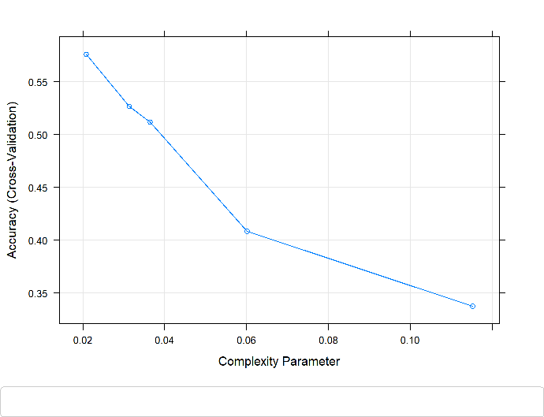

plot(mod_rf)

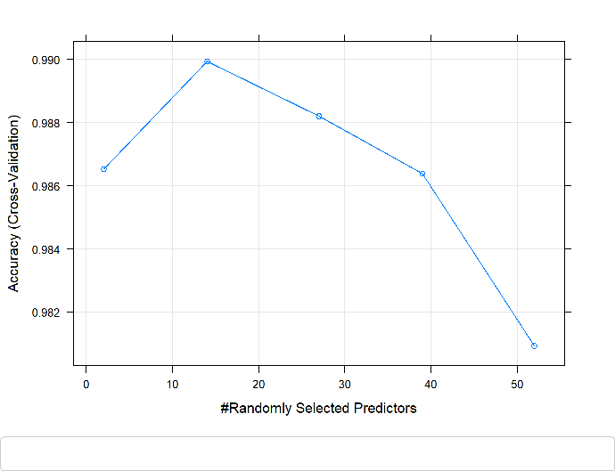

plot(mod_gbm)

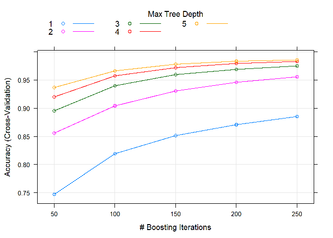